# MA415 Final Project - A Glance at London Restaurants

5/6/2018

## Outline

- Introduction
- Dataset
- Data Summary
- Food score vs. overall score
- Value score vs. overall score
- Service score vs. overall score
- Relationship among different scores
- Linear Regression
- Text Analysis on Review Text
- Sentiment Analysis on Review Text
- Text Analysis on Review Title
- Sentiment Analysis on Review Title
- Wordcloud
- Map

## Introduction

This analysis focus on online reviews and scores for restaurants, especially the factors behind the scores. We will look at factors such as different sector scores and location.

## What's the data set about?

- The dataset contains reviews and ratings of restaurants in the UK from year 2008 to 2017 from Tripadvisor. The goal is to take a closer look at factors behind the ratings, and how are restaurants in London overall.
- This dataset was created by PromptCloud's in-house web-crawling service.
- Original dataset can be found [here](https://data.world/promptcloud/london-based-restaurants-reviews-on-tripadvisor-co-uk)

## Data Summary

The first thing to do is to better tidying the data Only desirable variables are kept, and rating related variables are transformed into numeric.

Here is the summary of the tidy data:

|  | name | review_date | title | review_text | author | location | score | food | value | service | visited_on |
| --- | --- | --- | --- | --- | --- | --- | --- | --- | --- | --- | --- |
|  | Length:5561 | Min. :2008-06-28 | Length:5561 | Length:5561 | Length:5561 | Length:5561 | Min. :1.000 | Min. :1.000 | Min. :1.000 | Min. :1.000 | Length:5561 |
|  | Class :character | 1st Qu.:2014-04-10 | Class :character | Class :character | Class :character | Class :character | 1st Qu.:3.000 | 1st Qu.:3.000 | 1st Qu.:3.000 | 1st Qu.:3.000 | Class :character |
|  | Mode :character | Median :2015-07-12 | Mode :character | Mode :character | Mode :character | Mode :character | Median :4.000 | Median :4.000 | Median :4.000 | Median :4.000 | Mode :character |
|  | NA | Mean :2015-04-19 | NA | NA | NA | NA | Mean :3.922 | Mean :3.994 | Mean :3.739 | Mean :3.954 | NA |
|  | NA | 3rd Qu.:2016-07-21 | NA | NA | NA | NA | 3rd Qu.:5.000 | 3rd Qu.:5.000 | 3rd Qu.:5.000 | 3rd Qu.:5.000 | NA |
|  | NA | Max. :2017-07-24 | NA | NA | NA | NA | Max. :5.000 | Max. :5.000 | Max. :5.000 | Max. :5.000 | NA |
|  | NA | NA's :38 | NA | NA | NA | NA | NA's :149 | NA's :2308 | NA's :2246 | NA's :2208 | NA |

## food score vs. overall score

Now let's look at what we are interested in – restaurant ratings and potential factors.  
From the t-test, we can see that the food score and overall score have significantly different means.

```r
#t test on means of the scores
## overall score vs. food
t.test(by_res$score,by_res$food, na.action=na.omit)
```

```
##
##  Welch Two Sample t-test
##
## data:  by_res$score and by_res$food
## t = -2.6496, df = 6939.2, p-value = 0.008077
## alternative hypothesis: true difference in means is not equal to 0
## 95 percent confidence interval:
##  -0.12518115 -0.01871752
## sample estimates:
## mean of x mean of y
##  3.922210  3.994159
```

## value score vs. overall score

The second t-test shows that value score also has a significantly different mean from the overall score.

```r
## overall score vs. value
t.test(by_res$score,by_res$value, na.action=na.omit)
```

```
##
##  Welch Two Sample t-test
##
## data:  by_res$score and by_res$value
## t = 6.6065, df = 6853.4, p-value = 4.23e-11
## alternative hypothesis: true difference in means is not equal to 0
## 95 percent confidence interval:
##  0.1290136 0.2378798
## sample estimates:
## mean of x mean of y
##  3.922210  3.738763
```

## service score vs. overall score

```r
## overall score vs. service
t.test(by_res$score,by_res$service, na.action=na.omit)
```

```
##
##  Welch Two Sample t-test
##
## data:  by_res$score and by_res$service
## t = -1.1346, df = 6902.7, p-value = 0.2566
## alternative hypothesis: true difference in means is not equal to 0
## 95 percent confidence interval:
##  -0.08609731  0.02297164
## sample estimates:
## mean of x mean of y
##  3.922210  3.953773
```

## Linear Regression

```
##
## Call:
## lm(formula = score ~ food + value + service, data = by_res)
##
## Residuals:
##     Min      1Q  Median      3Q     Max
## -3.0064 -0.2161  0.0055  0.2681  3.4433
##
## Coefficients:
##              Estimate Std. Error t value Pr(>|t|)
## (Intercept) -0.209633   0.030205   -6.94 4.73e-12 ***
## food         0.463035   0.012091   38.30  < 2e-16 ***
## value        0.262509   0.011837   22.18  < 2e-16 ***
## service      0.315272   0.009535   33.07  < 2e-16 ***
## ---
## Signif. codes:  0 '***' 0.001 '**' 0.01 '*' 0.05 '.' 0.1 ' ' 1
##
## Residual standard error: 0.4667 on 3152 degrees of freedom
##   (2405 observations deleted due to missingness)
## Multiple R-squared:  0.8647, Adjusted R-squared:  0.8646
## F-statistic:  6716 on 3 and 3152 DF,  p-value: < 2.2e-16
```

## Linear Regression

- It is safe to say that the overall score is not the average of the other three scores.
- More specifically, food score occupies more proportion in overall score components than the other two.
- Afterall, food is what a restaurant is mainly about.

## Text Analysis - Reviews

Enough with the scores, let's look at what people say in their reviews.  
Here are the top words in reviews:

```
## # A tibble: 6 x 2
##   word           n
##   <chr>      <int>
## 1 food        4603
## 2 service     2637
## 3 restaurant  2206
## 4 staff       2007
## 5 menu        1385
## 6 time        1351
```

Again, food experience is very important to reviewers. We also see "service","staff" and "time" among the mostly used words, indicating the significance of service experience.

## Sentiment Analysis - Reviews

Reviewers express a lot of emotions in their reviews. How does sentiments in the reviews inpact the scores? Here is the sentiment-score analysis of reviews using the bing lexicon. Note that, \[sentiment = n_{pos words} - n_{neg words}\]

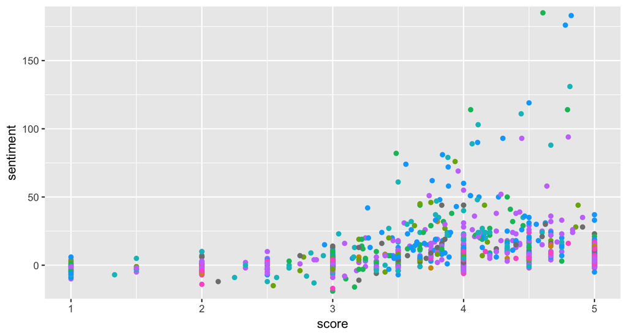

## Sentiment Analysis - Reviews

We see a positive relationship between sentiment and scores, except around score of 5. This could be due to a decrease in overall word counts for full-score reviews. Typically, those giving full scores can feel less needs to give detailed reviews. – Don't we all rate our Uber drivers 5 stars when things go well?

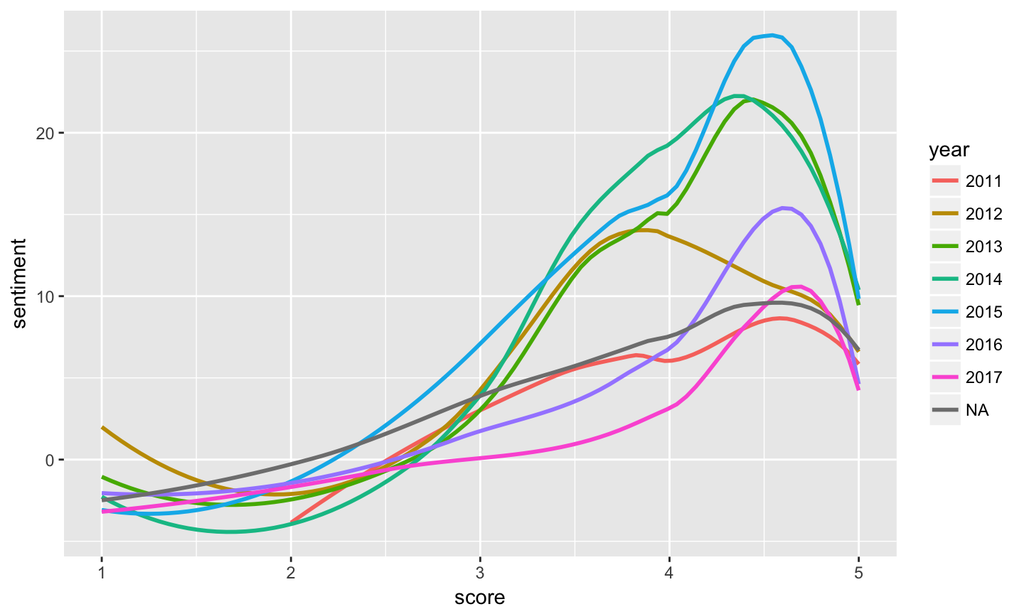

## Sentiment Analysis - Regression

Using linear regression, we can see that sentiment definitely has a positive relationship with score. The magnitude of the correlation varies lightly between different years.

```
##
## Call:
## lm(formula = sentiment ~ score, data = review_sentiments)
##
## Residuals:
##     Min      1Q  Median      3Q     Max
## -23.697  -6.244  -3.697   0.397 176.212
##
## Coefficients:
##             Estimate Std. Error t value Pr(>|t|)
## (Intercept)  -2.9438     1.4507  -2.029   0.0426 *
## score         2.5469     0.3519   7.237 6.94e-13 ***
## ---
## Signif. codes:  0 '***' 0.001 '**' 0.01 '*' 0.05 '.' 0.1 ' ' 1
##
## Residual standard error: 14.91 on 1686 degrees of freedom
##   (114 observations deleted due to missingness)
## Multiple R-squared:  0.03013,    Adjusted R-squared:  0.02955
## F-statistic: 52.37 on 1 and 1686 DF,  p-value: 6.941e-13
```

## Sentiment Analysis - Regression

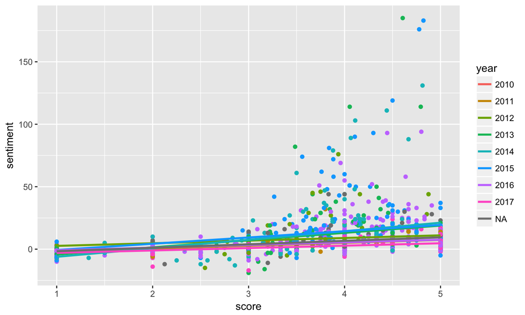

## Text Analysis - Review Titles

Let's also look at the texts in the review titles.  
Again, "food" is the top word.

```
## # A tibble: 2,727 x 2
##    word           n
##    <chr>      <int>
##  1 food        1074
##  2 service      587
##  3 excellent    267
##  4 restaurant   245
##  5 nice         214
##  6 london       199
##  7 lunch        184
##  8 lovely       182
##  9 amazing      170
## 10 delicious    153
## # ... with 2,717 more rows
```

## Sentiment Analysis - Review Titles

Looking at the sentiments of review titles, we see a much smaller range of sentiment values, which can be a result of the shorter length of titles.  
However, there is still a positive correlation between title sentiment and scores.

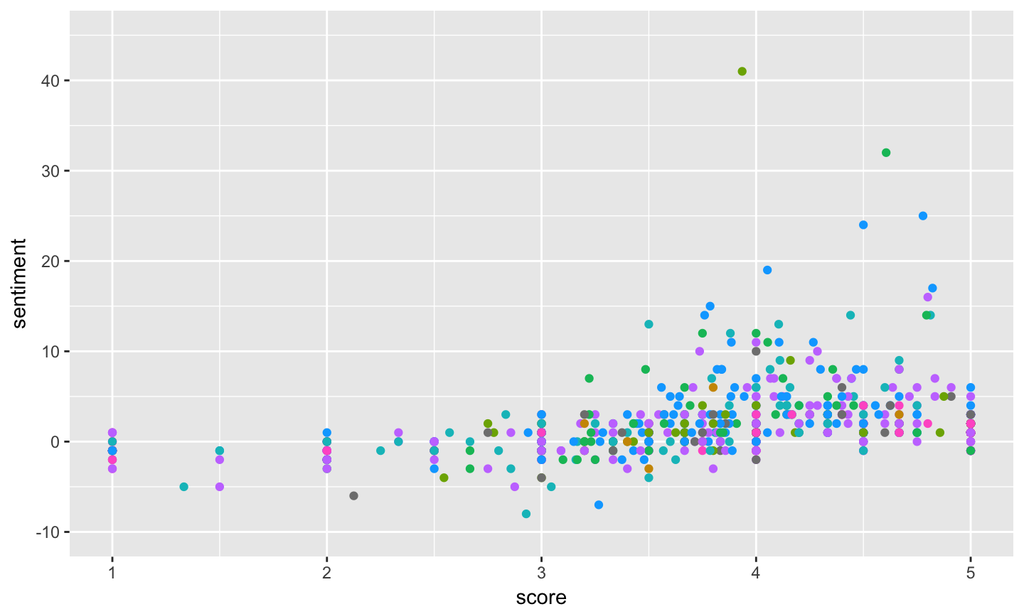

## Wordclouds

| Review Text Cloud | Review Title Cloud |
| --- | --- |

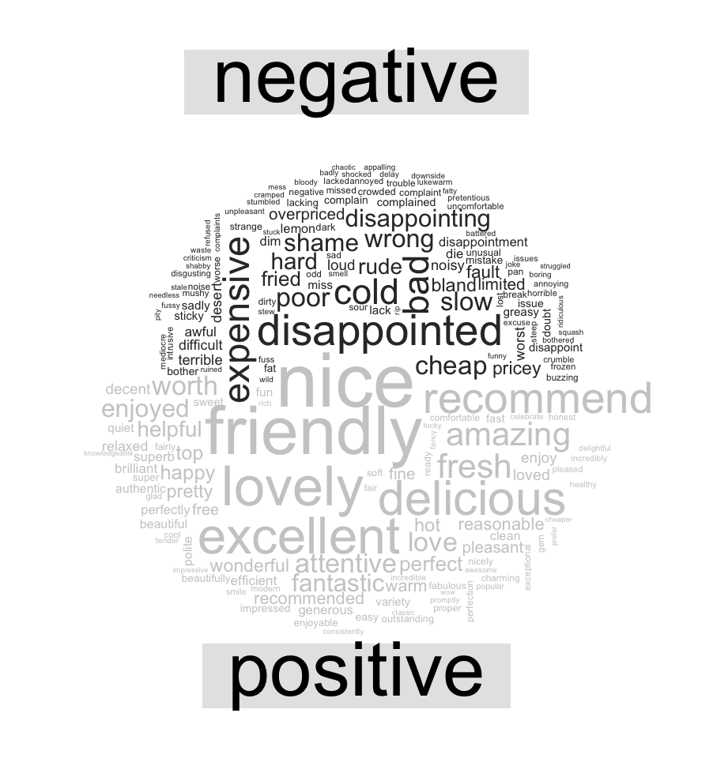

[output not shown]

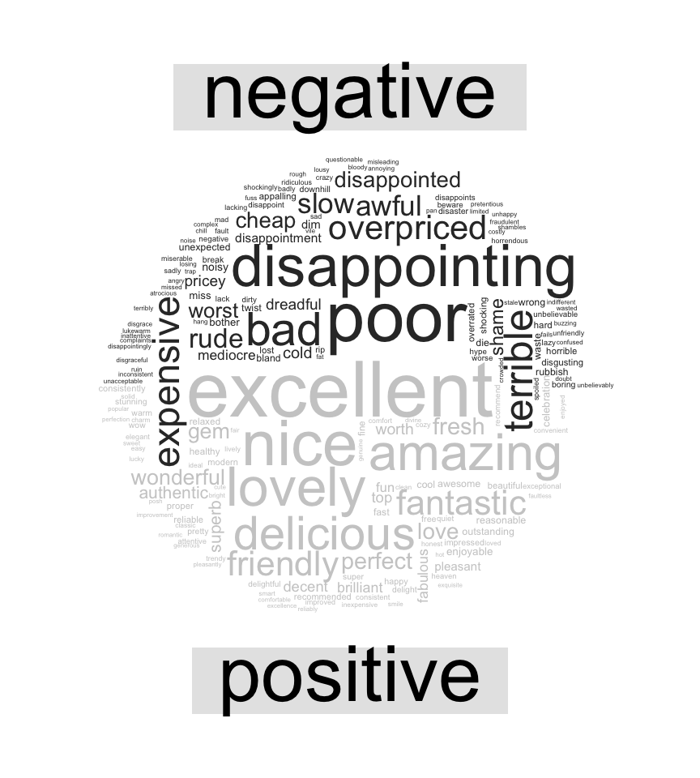

## Fantastic Restaurants and Where to Find Them

Check out where good restaurants are located in London.  
Note that central London has a lot of high-score restaurants, as well as low-score ones.  
There are areas with higher density of low-score than high-score places - Be aware!

[figure not shown]